# Lab 9: Tree-Based Methods

# 9.1 Fitting Regression Trees

The `tree` library is used to construct regression trees.

```r
library(tree)
library(ISLR2) # package contains datasets boston
attach(Boston)
```

Here we fit a regression tree to the `Boston` data set. First, we create a training set, and fit the tree to the training data.

```r
set.seed(1)
train <- sample(1:nrow(Boston), nrow(Boston) / 2)
tree.boston <- tree(medv ~ ., Boston, subset = train)
summary(tree.boston)
```

```
Regression tree:
tree(formula = medv ~ ., data = Boston, subset = train)
Variables actually used in tree construction:
[1] "rm"    "lstat" "crim"  "age"
Number of terminal nodes:  7
Residual mean deviance:  10.38 = 2555 / 246
Distribution of residuals:
    Min.  1st Qu.   Median     Mean  3rd Qu.     Max.
-10.1800  -1.7770  -0.1775   0.0000   1.9230  16.5800
```

Notice that the output of `summary()` indicates that only four of the variables have been used in constructing the tree. We now plot the tree.

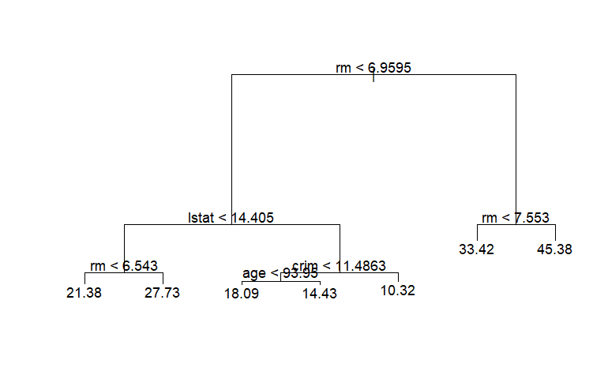

```r
plot(tree.boston)
text(tree.boston)
```

The variable `lstat` measures the percentage of individuals with lower socioeconomic status, while the variable `rm` corresponds to the average number of rooms. The tree indicates that larger values of rm, or lower values of `lstat`, correspond to more expensive houses. For example, the tree predicts a median house price of $45,400 for homes in census tracts in which `rm >=7.553`.

Now we use the `cv.tree()` function to see whether pruning the tree will improve performance.

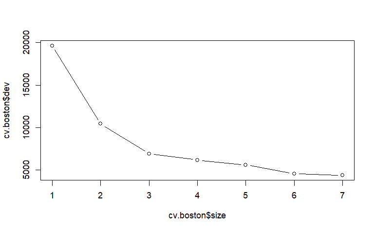

```r
cv.boston <- cv.tree(tree.boston)
plot(cv.boston$size, cv.boston$dev, type = "b")
```

In this case, the most complex tree under consideration is selected by cross-validation. However, if we wish to prune the tree, we could do so as follows,using the `prune.tree()` function:

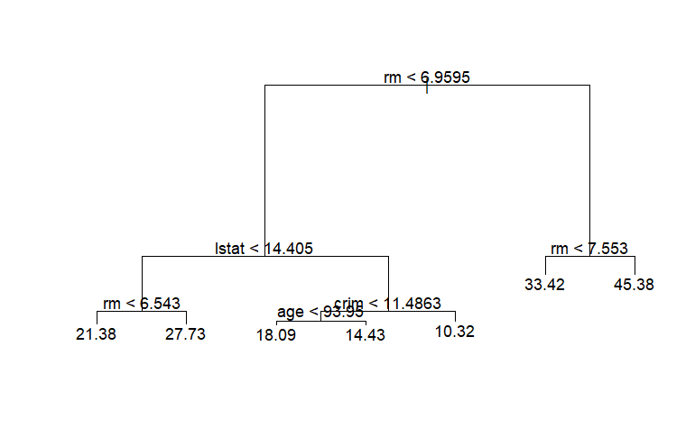

```r
prune.boston <- prune.tree(tree.boston, best = 7)
plot(prune.boston)
text(prune.boston, pretty = 0)
```

In keeping with the cross-validation results, we use the unpruned tree to make predictions on the test set.

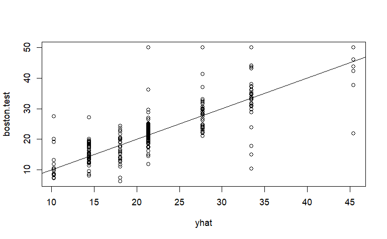

```r
yhat <- predict(tree.boston, newdata = Boston[-train, ])
yhat <- predict(prune.boston, newdata = Boston[-train, ])
boston.test <- Boston[-train, "medv"]
plot(yhat, boston.test)
abline(0, 1)
```

```r
mean((yhat - boston.test)^2)
```

```
[1] 35.28688
```

In other words, the test set MSE associated with the regression tree is 35.29.

# 9.2 Bagging and Random Forests

Here we apply bagging and random forests to the `Boston data`, using the `randomForest` package in `R`. Recall that bagging is simply a special case of a random forest with $m = p$. Therefore, the `randomForest()` function can be used to perform both random forests and bagging. We perform bagging as follows:

```r
library(randomForest)
set.seed(1)
bag.boston <- randomForest(medv ~ ., data = Boston,
                           subset = train, mtry = 12, importance = TRUE)
bag.boston
```

```
Call:
 randomForest(formula = medv ~ ., data = Boston, mtry = 12, importance = TRUE,      subset = train)
               Type of random forest: regression
                     Number of trees: 500
No. of variables tried at each split: 12

          Mean of squared residuals: 11.40162
                    % Var explained: 85.17
```

The argument `mtry = 12` indicates that all 12 predictors should be considered for each split of the tree—in other words, that bagging should be done. How well does this bagged model perform on the test set?

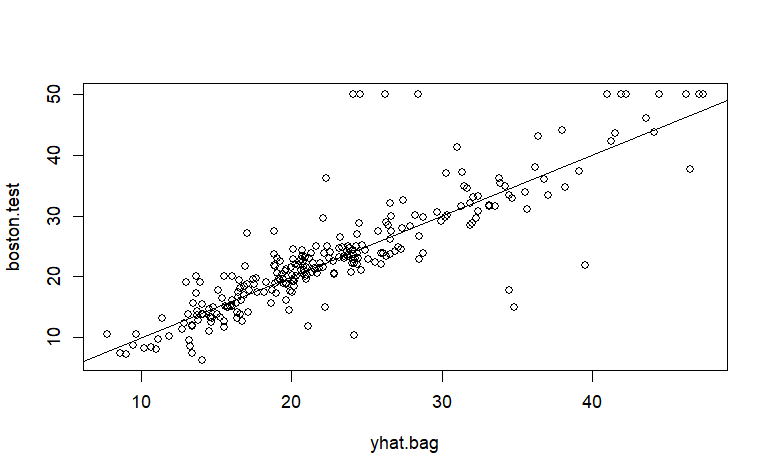

```r
yhat.bag <- predict(bag.boston, newdata = Boston[-train, ])
plot(yhat.bag, boston.test)
abline(0, 1)
```

```r
mean((yhat.bag - boston.test)^2)
```

```
[1] 23.41916
```

The test set MSE associated with the bagged regression tree is 23.42, about two-thirds of that obtained using an optimally-pruned single tree. We could change the number of trees grown by `randomForest()` using the `ntree` argument:

```r
bag.boston <- randomForest(medv ~ ., data = Boston,
                           subset = train, mtry = 12, ntree = 25)
yhat.bag <- predict(bag.boston, newdata = Boston[-train, ])
mean((yhat.bag - boston.test)^2)
```

```
[1] 25.75055
```

Growing a random forest proceeds in exactly the same way, except that we use a smaller value of the `mtry` argument. By default, `randomForest()`uses $p/3$ variables when building a random forest of regression trees, and √p variables when building a random forest of classification trees. Here we use `mtry = 6.`

```r
set.seed(1)
rf.boston <- randomForest(medv ~ ., data = Boston,
                          subset = train, mtry = 6, importance = TRUE)
yhat.rf <- predict(rf.boston, newdata = Boston[-train, ])
mean((yhat.rf - boston.test)^2)
```

```
[1] 20.06644
```

The test set MSE is 20.07; this indicates that random forests yielded an improvement over bagging in this case.

# 9.3 Boosting

Here we use the `gbm3` package, and within it the `gbm()` function, to fit boosted regression trees to the`Boston` data set. We run `gbm()` with the option `distribution = "gaussian"` since this is a regression problem; if it were a binary classification problem, we would use `distribution ="bernoulli".` The argument `n.trees = 5000` indicates that we want 5000 trees, and the option `interaction.depth = 4` limits the depth of each tree.

```r
library(gbm3)
set.seed(1)
boost.boston <- gbm(medv ~ ., data = Boston[train, ],
                    distribution = "gaussian", n.trees = 5000,
                    interaction.depth = 4)
```

We now use the boosted model to predict `medv` on the test set:

```r
yhat.boost <- predict(boost.boston,
                      newdata = Boston[-train, ], n.trees = 5000)
mean((yhat.boost - boston.test)^2)
```

```
[1] 21.51082
```

```r
boost.boston <- gbm(medv ~ ., data = Boston[train, ],
                    distribution = "gaussian", n.trees = 5000,
                    interaction.depth = 4, shrinkage = 0.2, verbose = F)
yhat.boost <- predict(boost.boston,
                      newdata = Boston[-train, ], n.trees = 5000)
mean((yhat.boost - boston.test)^2)
```

```
[1] 18.66251
```

In this case, using $λ =0.2$ leads to a lower test MSE than λ =0.001.

# 9.4 Bayesian Additive Regression Trees

In this section we use the `BART` package, and within it the `gbart()` function, to fit a Bayesian additive regression tree model to the Boston housing data set. The `gbart()` function is designed for quantitative outcome variables. For binary outcomes, `lbart()` and `pbart()` are available. To run the `gbart()` function, we must first create matrices of predictors for the training and test data. We run BART with default settings.

```r
library(BART)
x <- Boston[, 1:12]
y <- Boston[, "medv"]
xtrain <- x[train, ]
ytrain <- y[train]
xtest <- x[-train, ]
ytest <- y[-train]
set.seed(1)
bartfit <- gbart(xtrain, ytrain, x.test = xtest)
```

```
*****Calling gbart: type=1
*****Data:
data:n,p,np: 253, 12, 253
y1,yn: 0.213439, -5.486561
x1,x[n*p]: 0.109590, 20.080000
xp1,xp[np*p]: 0.027310, 7.880000
*****Number of Trees: 200
*****Number of Cut Points: 100 ... 100
*****burn,nd,thin: 100,1000,1
*****Prior:beta,alpha,tau,nu,lambda,offset: 2,0.95,0.795495,3,3.71636,21.7866
*****sigma: 4.367914
*****w (weights): 1.000000 ... 1.000000
*****Dirichlet:sparse,theta,omega,a,b,rho,augment: 0,0,1,0.5,1,12,0
*****printevery: 100

MCMC
done 0 (out of 1100)
done 100 (out of 1100)
done 200 (out of 1100)
done 300 (out of 1100)
done 400 (out of 1100)
done 500 (out of 1100)
done 600 (out of 1100)
done 700 (out of 1100)
done 800 (out of 1100)
done 900 (out of 1100)
done 1000 (out of 1100)
time: 2s
trcnt,tecnt: 1000,1000
```

Next we compute the test error.

```r
yhat.bart <- bartfit$yhat.test.mean
mean((ytest - yhat.bart)^2)
```

```
[1] 15.94718
```

On this data set, the test error of BART is lower than the test error of random forests and boosting.

# 9.5 Applying Random Forest for Spatiotemporal Prediction

We shall make use of

- `ape`, which is one of several packages that contain functionality for testing spatial or spatio-temporal independence with Moran’s I statistic;
- `FRK`, which contains functionality for constructing the basis functions

```r
library("ape")
library("FRK")
library("lattice")
library("RColorBrewer")
library("gstat")
library("sp")
library("spacetime")
library("STRbook")
library("tidyverse")
library("randomForest")
```

We again consider the NOAA data set, specifically the maximum temperature data for the month of July 1993. These data can be extracted as follows.

```r
data("NOAA_df_1990", package = "STRbook")
Tmax <- filter(NOAA_df_1990, # subset the data
               proc == "Tmax" & # only max temperature
                 month == 7 & # July
                 year == 1993) # year of 1993
```

The linear model we fit has the following form, with the list of basis functions:

$$Z(\textbf{s}_i,t_j) = \beta_0 + \beta_1X_1(\textbf{s}_i,t_j) + \cdots +
\beta_p X_p(\textbf{s}_i,t_j) + \alpha_1\phi_1(\textbf{s}_i,t_j) +
\cdots + \alpha_m\phi_m(\textbf{s}_i,t_j) + e(\textbf{s}_i,t_j)$$
The set of basis functions can be constructed using the function `auto_basis` in FRK. The function takes as arguments data, which is a spatial object; `nres`, which is the number of “resolutions” to construct; and `type`, which indicates the type of basis function to use.

```r
G <- auto_basis(data = Tmax[,c("lon","lat", "day")] %>% # Take Tmax
                  SpatialPoints(), # To sp obj
                nres = 3, # One resolution
                type = "Gaussian") # Gaussian BFs
```

These basis functions evaluated at data locations are then the covariates we seek for fitting the data. The functions are evaluated at any arbitrary location using the function `eval_basis`. This function requires the locations as a matrix object, and it returns the evaluations as an object of class `Matrix`, which can be easily converted to a `matrix` as follows.

```r
S <- eval_basis(basis = G, # basis functions
                s = Tmax[,c("lon","lat","day")] %>% # spat locations
                  as.matrix()) %>% # conv. to matrix
  as.matrix() # results as matrix

colnames(S) <- paste0("B", 1:ncol(S)) # assign column names
```

```r
Tmax2 <- cbind(Tmax, S) %>% # append S to Tmax
  select(-year, -month, -proc, # and remove vars we
         -julian, -date) # will not be using in
                          # the model
Tmax2
```

[output not shown]

We also remove 14 July 1993 to see how predictions on this day are affected, given that we have no data on that day.

```r
Tmax_no_14 <- filter(Tmax2, !(day == 14)) # remove day 14
```

```r
# Tmax_July_lm <- lm(z ~ (lon + lat + day)^2 + ., # model
# data = select(Tmax_no_14, -id)) # omit id

Tmax_July_lm <- randomForest(z ~ .,
              data = select(Tmax_no_14, -id), # omit id
              mtry = as.integer(sqrt(ncol(Tmax2))))

# Tmax_July_lm <- gbm(z ~ ., data = select(Tmax_no_14, -id),
#                     distribution = "gaussian", n.trees = 5000,
#                     interaction.depth = 4)

# Tmax_tmp = select(Tmax_no_14, -id)
# x <- Tmax_tmp[, -2]
# y <- Tmax_tmp[, "z"]
#
# set.seed(1)
# bartfit <- gbart(x, y)
```

The results of this fit can be viewed using `summary`.

```r
Tmax_July_lm %>% summary()
```

[output not shown]

Having fitted a spatio-temporal model, it is good practice to check the residuals.

```r
Tmax_no_14_2 = Tmax_no_14

# run this if bagging/random forest is used
# Tmax_no_14_2$residuals <- Tmax_July_lm$y - Tmax_July_lm$predicted
#residuals(Tmax_July_lm)

# run this if boosting is used
Tmax_no_14_2$residuals <- Tmax_no_14$z - Tmax_July_lm$fit

mean(Tmax_no_14_2$residuals^2)

g <- ggplot(filter(Tmax_no_14_2, day %in% 24:31)) +
  geom_point(aes(lon, lat, colour = residuals)) +
  facet_wrap(~ day, ncol=4) +
  col_scale(name = "degF") +
  geom_point(data = filter(Tmax_no_14,day %in% 24:31 &
                             id %in% c(3810, 3889)),
             aes(lon, lat), colour = "black",
             pch = 2, size = 2.5) +
  theme_bw()

g
```

[output not shown]

When the data are regularly spaced in time, as is the case here, one may also look at the “temporal” residuals at some location. For example, consider the maximum temperature (`Tmax`) residuals at stations 3810 and 3889.

```r
TS1 <- filter(Tmax_no_14_2, id == 3810)$residuals
TS2 <- filter(Tmax_no_14_2, id == 3889)$residuals

par(mar=c(4, 4, 1, 1))
plot(TS1, # Station 3810 residuals
     xlab = "day of July 1993",
     ylab = "residuals (degF)",
     type = 'o', ylim = c(-8, 7))
lines(TS2, # Station 3889 residuals
      xlab = "day of July 1993",
      ylab = "residuals (degF)",
      type = 'o', col = "red")
```

[output not shown]

Prediction from linear linear models in R is carried out using the function predict. We use the following prediction grid.

```r
pred_grid <- expand.grid(lon = seq(-100, -80, length = 20),
                         lat = seq(32, 46, length = 20),
                         day = seq(4, 29, length = 6))
```

```r
Spred <- eval_basis(basis = G, # basis functs
                    s = pred_grid[,c("lon","lat","day")] %>% # pred locs
                      as.matrix()) %>% # conv. to matrix
  as.matrix() # results as matrix

colnames(Spred) <- paste0("B", 1:ncol(Spred)) # assign col names
pred_grid <- cbind(pred_grid, Spred) # attach to grid
```

```r
linreg_pred <- predict(Tmax_July_lm,
                       newdata = pred_grid)

## Assign prediction to the prediction grid
pred_grid$z_pred <- linreg_pred
```

```r
ggplot(pred_grid) +
  geom_tile(aes(x=lon,y=lat,fill=z_pred)) +
  fill_scale(name = "degC") + theme_bw() +
  xlab("Longitude (deg)") + ylab("Latitude (deg)")
  facet_wrap(~day)
```

[output not shown]

```r
Tmax_14 <- filter(Tmax2, day == 14) # remove day 14

ggplot() +
  geom_tile(data=pred_grid, aes(x=lon,y=lat,fill=z_pred)) +
  geom_point(data=Tmax_14, aes(x=lon,y=lat,col=z, size=z), alpha=0.5) +
  col_scale(name = "degC")+
  fill_scale(name = "degC") + theme_bw() +
  xlab("Longitude (deg)") + ylab("Latitude (deg)")
  facet_wrap(~day)
```

[output not shown]